# S2MET Predictions Analysis

## Introduction

This notebook will outline some procedures to predict genotypic values in the presence of GxE by using a number of different models. Each model will be introduced, its assumptions outlined, predictions made, and results interpreted.

First we must define some directories and load packages

```r
library(tidyverse)
library(stringr)
library(rrBLUP)
library(readxl)
library(neyhart)
library(sommer)
library(gws)
# The head directory
proj_dir <- "C:/Users/Jeff/Google Drive/Barley Lab/Projects/S2MET/"
# Geno, pheno, and enviro data
geno_dir <-  "C:/Users/Jeff/Google Drive/Barley Lab/Projects/Genomic Selection/Genotypic Data/GBS Genotype Data/"
pheno_dir <- file.path(proj_dir, "Phenotype_Data/")
env_var_dir <- file.path(proj_dir, "Environmental_Variables")
# Other directories
fig_dir <- file.path(proj_dir, "Figures/")
pred_dir <- file.path(proj_dir, "Predictions")
entry_dir <- file.path(proj_dir, "Plant_Materials")
analysis_dir <- file.path(proj_dir, "Analysis")
result_dir <- file.path(proj_dir, "Results")
## Load Data
# Load the phenotypic data
load(file.path(pheno_dir, "S2_MET_BLUEs.RData"))
# Load the genotypic data
load(file.path(geno_dir, "S2_genos_mat.RData"))
# Load environmental data
load(file.path(env_var_dir, "environmental_data_compiled.RData"))
# Load an entry file
entry_list <- read_excel(file.path(entry_dir, "S2MET_project_entries.xlsx"))
# Grab the entry names that are not checks
tp <- entry_list %>%
  filter(Class == "S2TP") %>%
  pull(Line)
vp <- entry_list %>%
  filter(Class == "S2C1R") %>%
  pull(Line)
# Find the tp and vp that are genotypes
tp_geno <- intersect(tp, row.names(s2_imputed_mat))
vp_geno <- intersect(vp, row.names(s2_imputed_mat))
# Define the checks
checks <- entry_list %>%
  filter(Class == "Check") %>%
  pull(Line)
entries <- entry_list %>%
  pull(Line)
# Extract the tp and vp from the G matrix
s2_imputed_mat_use <- s2_imputed_mat[c(tp_geno, vp_geno),]
```

## Methods

### Simple Genomic Predictions

This section will cover the simple intra and inter-environmental predictions.

#### Intra-Environmental Predictions

Predictionswere conducted using the model

$$\mathbf{y = X \beta + Z u + e}$$

where $\mathbf{u}$ was modelled such that $\mathbf{u} \sim N(0, \sigma^2_u \mathbf{A})$ and $\mathbf{e}$ was modelled such that $\mathbf{e} \sim N(0, \sigma^2_\epsilon \mathbf{R})$. The matrix $\mathbf{R}$ was a diagonal matrix with elements equal to the inverse squares of the standard errors of the BLUEs present in $\mathbf{y}$.

For each environment in which the training population was evaluated along with the validation population, predict the vp phenotypes using the tp.

Analysis

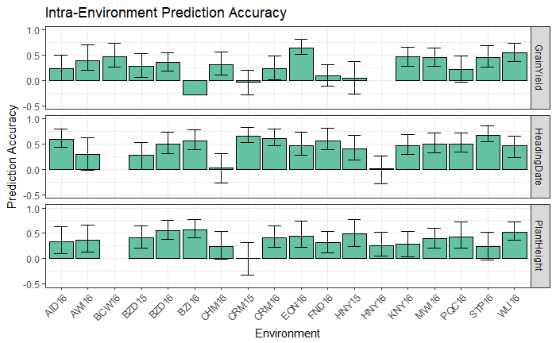

Combine with heritability information and compare. For 2015 trials (where there was a separate tp and vp trial), only use the heritability information for the vp trials

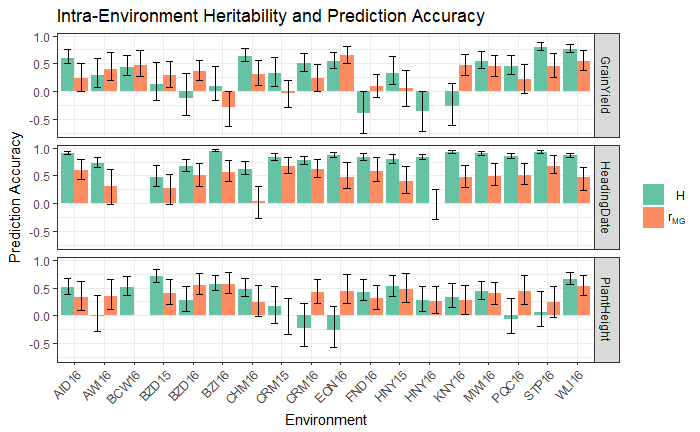

What is the correlation between heritability and prediction accuracy?

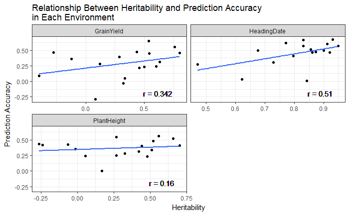